# News Sarcams Detection

Lohansen

2019-08-28

```r
library(rjson)
library(jsonlite)
library(tidyverse)
library(tm)
library(e1071)
library(caret)
library(ROCR)
```

# Briefs

In this LBB, I want to make a sarcasm detector using modeling naivebayes machine learning to predict whether a headline written is sarcasm or not. The dataset I use is **News Headlines dataset for Sarcasm Detection** which is data taken from comments from the news website **The Onion** and **HuffPost**

dataset ini berasal dari https://www.kaggle.com/rmisra/news-headlines-dataset-for-sarcasm-detection. Each record consists of three attributes:

- is_sarcastic: 1 if the record is sarcastic otherwise 0
- headline: the headline of the news article
- article_link: link to the original news article. Useful in collecting supplementary data

# Read Data

```r
data2 <- file("news-headlines-dataset-for-sarcasm-detection/Sarcasm_Headlines_Dataset_v2.json") %>%
  stream_in()
```

```
## opening file input connection.
```

[output not shown]

```
## closing file input connection.
```

```r
sarcasm <- data2 %>%
  select("label" = is_sarcastic, "text" = headline) %>%
  mutate("label" = as.factor(label))

sarcasm <- sarcasm[1:7000,]

head(sarcasm)
```

```
##   label
## 1     1
## 2     0
## 3     0
## 4     1
## 5     1
## 6     0
##                                                                              text
## 1                   thirtysomething scientists unveil doomsday clock of hair loss
## 2 dem rep. totally nails why congress is falling short on gender, racial equality
## 3                               eat your veggies: 9 deliciously different recipes
## 4                            inclement weather prevents liar from getting to work
## 5                   mother comes pretty close to using word 'streaming' correctly
## 6                                                            my white inheritance
```

# Data Manipulation (Text-Mining)

### STEP 1 : Convert text to corpus

```r
sarcasm.corpus <- VCorpus(VectorSource(sarcasm$text))
```

### STEP 2 : Text Prepocesing

1. Convert all text to lower case

```r
sarcasm.corpus <- tm_map(sarcasm.corpus, content_transformer(tolower))
```

2. Remove ‘stopwords’ and numbers

```r
sarcasm.corpus <- tm_map(sarcasm.corpus, removeNumbers)
sarcasm.corpus <- tm_map(sarcasm.corpus, removeWords, stopwords("english"))
```

3. Remove common punctuations

```r
sarcasm.corpus <- tm_map(sarcasm.corpus, removePunctuation)
```

4. Replace special symbol/punctuation with a white space (Skip)
5. Stemming

```r
sarcasm.corpus <- tm_map(sarcasm.corpus, stemDocument)
```

### STEP 3 : Tokenization

```r
sarcasm.dtm <- DocumentTermMatrix(sarcasm.corpus)
sarcasm.dtm
```

```
## <<DocumentTermMatrix (documents: 7000, terms: 9890)>>
## Non-/sparse entries: 48922/69181078
## Sparsity           : 100%
## Maximal term length: 26
## Weighting          : term frequency (tf)
```

```r
inspect(sarcasm.dtm)
```

```
## <<DocumentTermMatrix (documents: 7000, terms: 9890)>>
## Non-/sparse entries: 48922/69181078
## Sparsity           : 100%
## Maximal term length: 26
## Weighting          : term frequency (tf)
## Sample             :
##       Terms
## Docs   day get just make man new report say time trump
##   1238   0   0    0    0   0   0      0   0    0     0
##   1420   0   0    0    0   0   0      0   0    0     0
##   1450   0   0    0    0   1   0      0   0    0     0
##   2147   0   0    0    0   0   0      0   0    0     0
##   238    0   0    0    0   0   0      0   0    0     0
##   2427   0   1    0    0   0   1      1   0    0     0
##   2609   0   0    0    0   0   0      0   0    0     0
##   3310   0   0    0    0   0   0      0   0    0     1
##   4689   0   0    0    0   0   0      0   0    0     0
##   620    0   0    0    0   1   0      0   0    0     0
```

Interpretation : an inspection conducted on the corpus sarcasm data that was changed with the `DocumentTermMatrix` function showed the 10 most used words in 7000 news headlines taken from this data

these are the word with minimum 200x have used in comment on this data

```r
findFreqTerms(sarcasm.dtm, 200)
```

```
## [1] "get"   "man"   "new"   "say"   "trump"
```

### Step 4 : Cross-Validation

First, let split the train-test for the predictor only.

```r
set.seed(100)

index <- sample(1:nrow(sarcasm.dtm), 0.80*nrow(sarcasm.dtm))

sarcasm_train <- sarcasm.dtm[index,]
sarcasm_test <- sarcasm.dtm[-index,]
```

split the sarcasm label

```r
train_label <- sarcasm[index,1]
test_label <- sarcasm[-index,1]
```

```r
# All ...
sarcasm_freq <- findFreqTerms(sarcasm.dtm, 20)

sarcasm_train <- sarcasm_train[,sarcasm_freq]
sarcasm_test <- sarcasm_test[,sarcasm_freq]
```

### STEP 6 : Convert to 0 and 1

```r
bernoulli_conv <- function(x){
  x <- as.factor(ifelse(x > 0, 1, 0))
}
```

```r
train_bn <- apply(sarcasm_train, 2, bernoulli_conv)

test_bn <- apply(sarcasm_test, 2, bernoulli_conv)
```

### STEP 7 : Modelling

```r
sarcasm_model <- naiveBayes(x = train_bn, y = train_label)
sarcasm_predict <- predict(sarcasm_model, test_bn, type = "class")
```

### STEP 8 : COnfusion Matrix

```r
confusionMatrix(
  data = sarcasm_predict,
  reference = test_label,
  dnn = c("Prediksi", "Aktual"),
  positive = "0")
```

```
## Confusion Matrix and Statistics
##
##         Aktual
## Prediksi   0   1
##        0 529 241
##        1 225 405
##
##                Accuracy : 0.6671
##                  95% CI : (0.6418, 0.6918)
##     No Information Rate : 0.5386
##     P-Value [Acc > NIR] : <2e-16
##
##                   Kappa : 0.3291
##
##  Mcnemar's Test P-Value : 0.4871
##
##             Sensitivity : 0.7016
##             Specificity : 0.6269
##          Pos Pred Value : 0.6870
##          Neg Pred Value : 0.6429
##              Prevalence : 0.5386
##          Detection Rate : 0.3779
##    Detection Prevalence : 0.5500
##       Balanced Accuracy : 0.6643
##
##        'Positive' Class : 0
##
```

### STEP 9 : Evaluating and Improving

```r
sarcasm_prediction_raw <- predict(sarcasm_model, test_bn, type = "raw")
head(sarcasm_prediction_raw)
```

```
##              0         1
## [1,] 0.5135103 0.4864897
## [2,] 0.7222605 0.2777395
## [3,] 0.2995397 0.7004603
## [4,] 0.2878520 0.7121480
## [5,] 0.2827446 0.7172554
## [6,] 0.4154551 0.5845449
```

treshold : 0.3

```r
sarcasm.predict2 <- as.factor(ifelse(sarcasm_prediction_raw[,2] >= 0.3, 1, 0))
```

```r
confusionMatrix(
  data = sarcasm.predict2,
  reference = test_label,
  dnn = c("Prediksi", "Aktual"),
  positive = "0")
```

```
## Confusion Matrix and Statistics
##
##         Aktual
## Prediksi   0   1
##        0 310  89
##        1 444 557
##
##                Accuracy : 0.6193
##                  95% CI : (0.5933, 0.6448)
##     No Information Rate : 0.5386
##     P-Value [Acc > NIR] : 6.429e-10
##
##                   Kappa : 0.263
##
##  Mcnemar's Test P-Value : < 2.2e-16
##
##             Sensitivity : 0.4111
##             Specificity : 0.8622
##          Pos Pred Value : 0.7769
##          Neg Pred Value : 0.5564
##              Prevalence : 0.5386
##          Detection Rate : 0.2214
##    Detection Prevalence : 0.2850
##       Balanced Accuracy : 0.6367
##
##        'Positive' Class : 0
##
```

### STEP 10 : checking the ROC

As the requirement of ROC curve, I provide our model prediction and the actual class.

```r
sarcasm_df <- data.frame("prediction"=sarcasm_prediction_raw[,2], "trueclass"=as.numeric(test_label=="0"))
head(sarcasm_df)
```

```
##   prediction trueclass
## 1  0.4864897         1
## 2  0.2777395         0
## 3  0.7004603         1
## 4  0.7121480         0
## 5  0.7172554         1
## 6  0.5845449         1
```

ROC curve is a plot of Sensitivity respect to Loss of Specificity given all possible threshold.

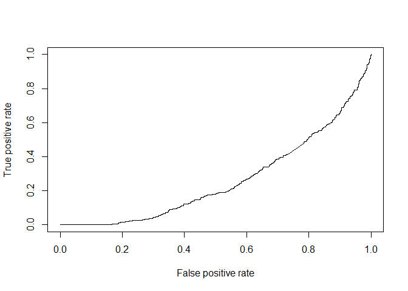

```r
sarcasm_roc <- prediction(sarcasm_df$prediction, sarcasm_df$trueclass)
plot(performance(sarcasm_roc, "tpr", "fpr"))
```

Interpretation : ROC is one of the additional evaluations used to assess whether this model has a good significance level or not. in the ROC test this time, it appears that the results obtained are very much less than they should be, the ROC plot above indicates that if you want to increase the True Positive Rate, it requires considerable struggle, because there is a large gap every increase in the True Positive Rate against False Positive Rate. for that I consider that this model is not suitable for use, moreover this model has a level of accuracy that is not good only around 60% -65% (although the treshold has been changed). this is probably due to this model using text mining prepocessing with the TM basic library so that the results obtained are not significant. for that the solution is to try another method like **tidytext bigrams** or the **lematization** method to get better results.

Conclusion : Through this text mining prediction model, I want to create a machine learning that can predict whether headlines on news websites contain sarcasm or not. This prediction model can be used for the needs of news portal companies to sort headlines like this and make further improvements.

After testing the sarcasm prediction model, I found that there was a significant lack of accuracy in this model so that it was not suitable for use, because this model was made with basic TM prepocessing which could only use one word as terms, unable to interpret words words that have opposite meanings. For this reason, it is need other libraries such as tidytext bigrams or lematization for the development of this model to make it better.